# Manual model development

author: “Del Middlemiss”  
date: “16th August 2019”

# 1 MVP

You are given a set of data on housing sale prices for the last few years in King County (near Seattle) between May 2014 and May 2015.

We want you to build an **explanatory model** for the `price` of housing in King County, i.e. an interpretable model in which the included variables are statistically justifiable.

The variable definitions are:

`id` - Unique ID for each home sold  
`date` - Date of the home sale  
`price` - Price of each home sold  
`bedrooms` - Number of bedrooms  
`bathrooms` - Number of bathrooms, where .5 accounts for a room with a toilet but no shower  
`sqft_living` - Square footage of the apartments interior living space  
`sqft_lot` - Square footage of the land space  
`floors` - Number of floors  
`waterfront` - A dummy variable for whether the apartment was overlooking the waterfront or not  
`view` - An index from 0 to 4 of how good the view of the property was  
`condition` - An index from 1 to 5 on the condition of the apartment  
`grade` - An index from 1 to 13, where 1-3 falls short of building construction and design, 7 has an average level of construction and design, and 11-13 have a high quality level of construction and design  
`sqft_above` - The square footage of the interior housing space that is above ground level  
`sqft_basement` - The square footage of the interior housing space that is below ground level  
`yr_built` - The year the house was initially built  
`yr_renovated` - The year of the house’s last renovation  
`zipcode` - What zipcode area the house is in  
`lat` - Lattitude  
`long` - Longitude  
`sqft_living15` - The square footage of interior housing living space for the nearest 15 neighbors  
`sqft_lot15` - The square footage of the land lots of the nearest 15 neighbors

- Tidy up the data ready for regression:
  - You might like to think about removing some or all of `date`, `id`, `sqft_living15`, `sqft_lot15` and `zipcode` (`lat` and `long` provide a better measure of location in any event).
  - Have a think about how to treat `waterfront`. Should we convert its type?
  - We converted `yr_renovated` into a `renovated` logical variable, indicating whether the property had ever been renovated. You may wish to do the same.
  - Have a think about how to treat `condition` and `grade`? Are they interval or categorical ordinal data types?

**Solution**

```r
library(tidyverse)
library(GGally)
library(modelr)
```

```r
houses <- read_csv("data/kc_house_data.csv")
glimpse(houses)
```

```
## Rows: 21,613
## Columns: 21
## $ id            <chr> "7129300520", "6414100192", "5631500400", "2487200875",…
## $ date          <dttm> 2014-10-13, 2014-12-09, 2015-02-25, 2014-12-09, 2015-0…
## $ price         <dbl> 221900, 538000, 180000, 604000, 510000, 1225000, 257500…
## $ bedrooms      <dbl> 3, 3, 2, 4, 3, 4, 3, 3, 3, 3, 3, 2, 3, 3, 5, 4, 3, 4, 2…
## $ bathrooms     <dbl> 1.00, 2.25, 1.00, 3.00, 2.00, 4.50, 2.25, 1.50, 1.00, 2…
## $ sqft_living   <dbl> 1180, 2570, 770, 1960, 1680, 5420, 1715, 1060, 1780, 18…
## $ sqft_lot      <dbl> 5650, 7242, 10000, 5000, 8080, 101930, 6819, 9711, 7470…
## $ floors        <dbl> 1.0, 2.0, 1.0, 1.0, 1.0, 1.0, 2.0, 1.0, 1.0, 2.0, 1.0, …
## $ waterfront    <dbl> 0, 0, 0, 0, 0, 0, 0, 0, 0, 0, 0, 0, 0, 0, 0, 0, 0, 0, 0…
## $ view          <dbl> 0, 0, 0, 0, 0, 0, 0, 0, 0, 0, 0, 0, 0, 0, 0, 3, 0, 0, 0…
## $ condition     <dbl> 3, 3, 3, 5, 3, 3, 3, 3, 3, 3, 3, 4, 4, 4, 3, 3, 3, 4, 4…
## $ grade         <dbl> 7, 7, 6, 7, 8, 11, 7, 7, 7, 7, 8, 7, 7, 7, 7, 9, 7, 7, …
## $ sqft_above    <dbl> 1180, 2170, 770, 1050, 1680, 3890, 1715, 1060, 1050, 18…
## $ sqft_basement <dbl> 0, 400, 0, 910, 0, 1530, 0, 0, 730, 0, 1700, 300, 0, 0,…
## $ yr_built      <dbl> 1955, 1951, 1933, 1965, 1987, 2001, 1995, 1963, 1960, 2…
## $ yr_renovated  <dbl> 0, 1991, 0, 0, 0, 0, 0, 0, 0, 0, 0, 0, 0, 0, 0, 0, 0, 0…
## $ zipcode       <dbl> 98178, 98125, 98028, 98136, 98074, 98053, 98003, 98198,…
## $ lat           <dbl> 47.5112, 47.7210, 47.7379, 47.5208, 47.6168, 47.6561, 4…
## $ long          <dbl> -122.257, -122.319, -122.233, -122.393, -122.045, -122.…
## $ sqft_living15 <dbl> 1340, 1690, 2720, 1360, 1800, 4760, 2238, 1650, 1780, 2…
## $ sqft_lot15    <dbl> 5650, 7639, 8062, 5000, 7503, 101930, 6819, 9711, 8113,…
```

```r
# tidy up data. In particular treat condition and grade as factor, as they are
# ordinal categorical
houses_tidy <- houses %>%
  select(-c("id", "date", "sqft_living15", "sqft_lot15", "zipcode")) %>%
  mutate(waterfront = as.logical(waterfront)) %>%
  mutate(renovated = yr_renovated != 0) %>%
  select(-"yr_renovated") %>%
  mutate(condition = as_factor(condition)) %>%
  mutate(grade = as_factor(grade))

glimpse(houses_tidy)
```

```
## Rows: 21,613
## Columns: 16
## $ price         <dbl> 221900, 538000, 180000, 604000, 510000, 1225000, 257500…
## $ bedrooms      <dbl> 3, 3, 2, 4, 3, 4, 3, 3, 3, 3, 3, 2, 3, 3, 5, 4, 3, 4, 2…
## $ bathrooms     <dbl> 1.00, 2.25, 1.00, 3.00, 2.00, 4.50, 2.25, 1.50, 1.00, 2…
## $ sqft_living   <dbl> 1180, 2570, 770, 1960, 1680, 5420, 1715, 1060, 1780, 18…
## $ sqft_lot      <dbl> 5650, 7242, 10000, 5000, 8080, 101930, 6819, 9711, 7470…
## $ floors        <dbl> 1.0, 2.0, 1.0, 1.0, 1.0, 1.0, 2.0, 1.0, 1.0, 2.0, 1.0, …
## $ waterfront    <lgl> FALSE, FALSE, FALSE, FALSE, FALSE, FALSE, FALSE, FALSE,…
## $ view          <dbl> 0, 0, 0, 0, 0, 0, 0, 0, 0, 0, 0, 0, 0, 0, 0, 3, 0, 0, 0…
## $ condition     <fct> 3, 3, 3, 5, 3, 3, 3, 3, 3, 3, 3, 4, 4, 4, 3, 3, 3, 4, 4…
## $ grade         <fct> 7, 7, 6, 7, 8, 11, 7, 7, 7, 7, 8, 7, 7, 7, 7, 9, 7, 7, …
## $ sqft_above    <dbl> 1180, 2170, 770, 1050, 1680, 3890, 1715, 1060, 1050, 18…
## $ sqft_basement <dbl> 0, 400, 0, 910, 0, 1530, 0, 0, 730, 0, 1700, 300, 0, 0,…
## $ yr_built      <dbl> 1955, 1951, 1933, 1965, 1987, 2001, 1995, 1963, 1960, 2…
## $ lat           <dbl> 47.5112, 47.7210, 47.7379, 47.5208, 47.6168, 47.6561, 4…
## $ long          <dbl> -122.257, -122.319, -122.233, -122.393, -122.045, -122.…
## $ renovated     <lgl> FALSE, TRUE, FALSE, FALSE, FALSE, FALSE, FALSE, FALSE, …
```

- Check for aliased variables using the `alias()` function (this takes in a formula object and a data set). [**Hint** - formula `price ~ .` says ‘price varying with all predictors’, this is a suitable input to `alias()`]. Remove variables that lead to an alias. Check the ‘Elements of multiple regression’ lesson for a dropdown containing further information on finding aliased variables in a dataset.

**Solution**

```r
# Alias is useful to check if we have aliased variables, i.e. one or more
# variables that can be computed from other variables
alias(price ~ ., data = houses_tidy)
```

```
## Model :
## price ~ bedrooms + bathrooms + sqft_living + sqft_lot + floors +
##     waterfront + view + condition + grade + sqft_above + sqft_basement +
##     yr_built + lat + long + renovated
##
## Complete :
##               (Intercept) bedrooms bathrooms sqft_living sqft_lot floors
## sqft_basement  0           0        0         1           0        0
##               waterfrontTRUE view condition2 condition3 condition4 condition5
## sqft_basement  0              0    0          0          0          0
##               grade3 grade4 grade5 grade6 grade7 grade8 grade9 grade10 grade11
## sqft_basement  0      0      0      0      0      0      0      0       0
##               grade12 grade13 sqft_above yr_built lat long renovatedTRUE
## sqft_basement  0       0      -1          0        0   0    0
```

```r
# seems that sqft_basement can be computed from sqft_living - sqft_above.
# let's drop sqft_living leaving just the two contributions sqft_basement and
# sqft_above
houses_tidy <- houses_tidy %>%
  select(-"sqft_living")

glimpse(houses_tidy)
```

```
## Rows: 21,613
## Columns: 15
## $ price         <dbl> 221900, 538000, 180000, 604000, 510000, 1225000, 257500…
## $ bedrooms      <dbl> 3, 3, 2, 4, 3, 4, 3, 3, 3, 3, 3, 2, 3, 3, 5, 4, 3, 4, 2…
## $ bathrooms     <dbl> 1.00, 2.25, 1.00, 3.00, 2.00, 4.50, 2.25, 1.50, 1.00, 2…
## $ sqft_lot      <dbl> 5650, 7242, 10000, 5000, 8080, 101930, 6819, 9711, 7470…
## $ floors        <dbl> 1.0, 2.0, 1.0, 1.0, 1.0, 1.0, 2.0, 1.0, 1.0, 2.0, 1.0, …
## $ waterfront    <lgl> FALSE, FALSE, FALSE, FALSE, FALSE, FALSE, FALSE, FALSE,…
## $ view          <dbl> 0, 0, 0, 0, 0, 0, 0, 0, 0, 0, 0, 0, 0, 0, 0, 3, 0, 0, 0…
## $ condition     <fct> 3, 3, 3, 5, 3, 3, 3, 3, 3, 3, 3, 4, 4, 4, 3, 3, 3, 4, 4…
## $ grade         <fct> 7, 7, 6, 7, 8, 11, 7, 7, 7, 7, 8, 7, 7, 7, 7, 9, 7, 7, …
## $ sqft_above    <dbl> 1180, 2170, 770, 1050, 1680, 3890, 1715, 1060, 1050, 18…
## $ sqft_basement <dbl> 0, 400, 0, 910, 0, 1530, 0, 0, 730, 0, 1700, 300, 0, 0,…
## $ yr_built      <dbl> 1955, 1951, 1933, 1965, 1987, 2001, 1995, 1963, 1960, 2…
## $ lat           <dbl> 47.5112, 47.7210, 47.7379, 47.5208, 47.6168, 47.6561, 4…
## $ long          <dbl> -122.257, -122.319, -122.233, -122.393, -122.045, -122.…
## $ renovated     <lgl> FALSE, TRUE, FALSE, FALSE, FALSE, FALSE, FALSE, FALSE, …
```

- Systematically build a regression model containing up to **four** main effects (remember, a main effect is just a single predictor with coefficient), testing the regression diagnostics as you go
  - splitting datasets into numeric and non-numeric columns might help `ggpairs()` run in manageable time, although you will need to add either a `price` or `resid` column to the non-numeric dataframe in order to see its correlations with the non-numeric predictors.

**Hints**

```r
houses_tidy_numeric <- houses_tidy %>%
  select_if(is.numeric)

houses_tidy_nonnumeric <- houses_tidy %>%
  select_if(function(x) !is.numeric(x))

houses_tidy_nonnumeric$price <- houses_tidy$price

ggpairs(houses_tidy_numeric)
ggpairs(houses_tidy_nonnumeric)
```

and the same in subsequent rounds of predictor selection with the `resid` column.  
Remember, if you are not sure whether including a categorical predictor is statistically justified, run an `anova()` test passing in the models with- and without the categorical predictor and check the p-value of the test.

**Solution**

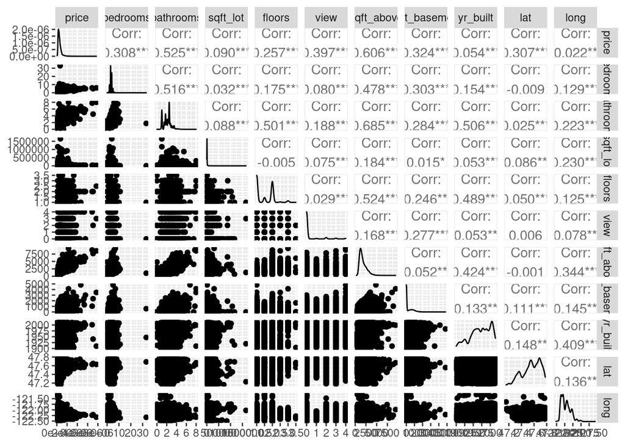

```r
houses_tidy_numeric <- houses_tidy %>%
  select_if(is.numeric)

houses_tidy_nonnumeric <- houses_tidy %>%
  select_if(function(x) !is.numeric(x))

houses_tidy_nonnumeric$price <- houses_tidy$price

ggpairs(houses_tidy_numeric)
```

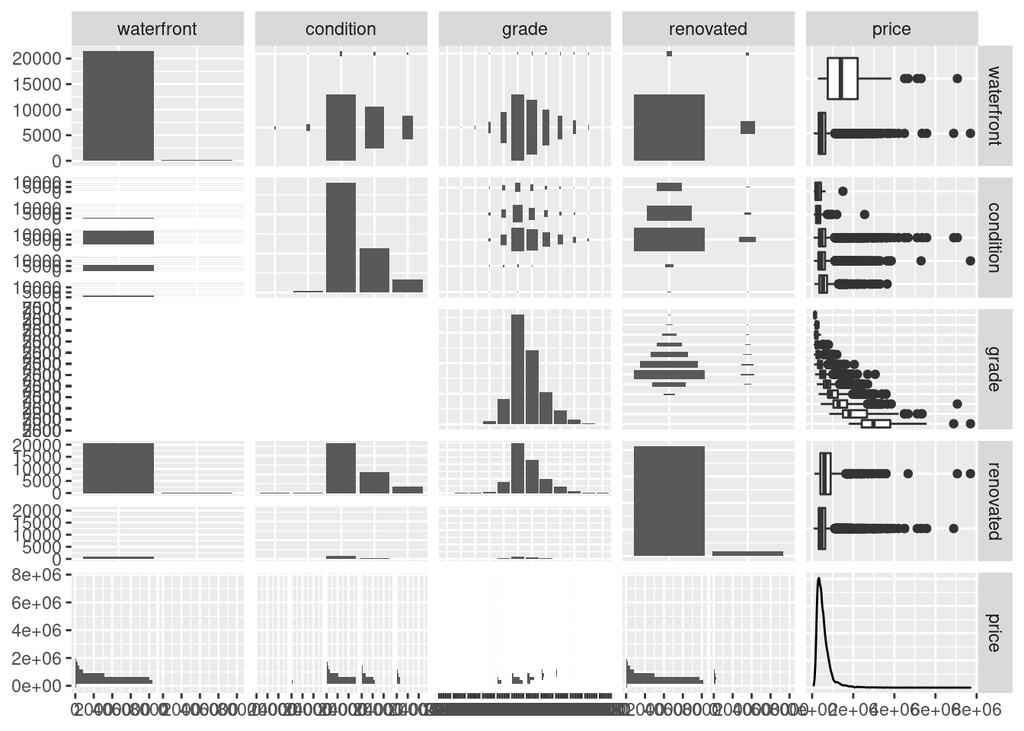

```r
ggpairs(houses_tidy_nonnumeric)
```

Correlation of `sqft_above` with `price` looks pretty promising, but split of `price` by `grade` and `waterfront` also look decent.

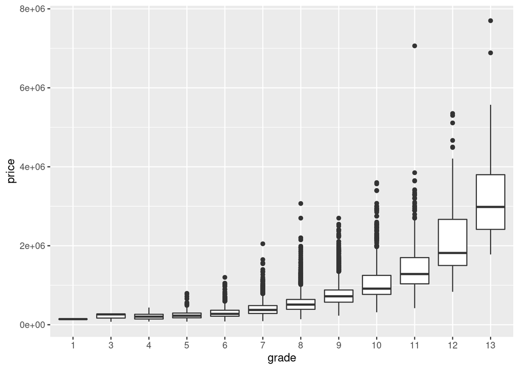

```r
houses_tidy %>%
  ggplot(aes(x = grade, y = price)) +
  geom_boxplot()
```

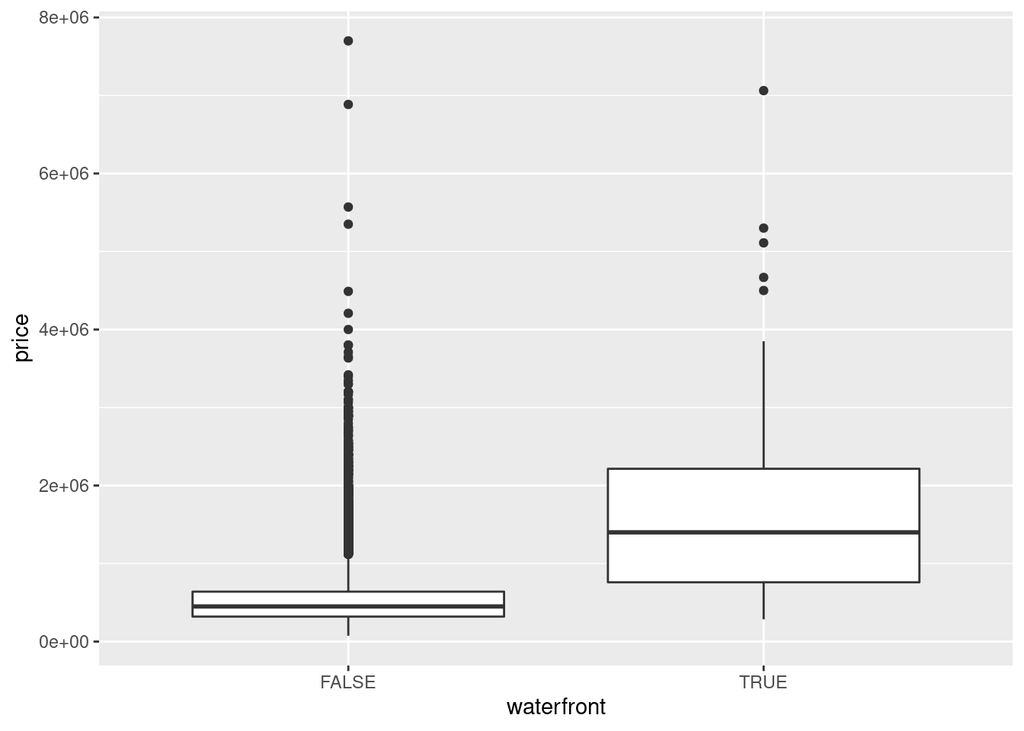

```r
houses_tidy %>%
  ggplot(aes(x = waterfront, y = price)) +
  geom_boxplot()
```

```r
mod1a <- lm(price ~ sqft_above, data = houses_tidy)
summary(mod1a)
```

```
##
## Call:
## lm(formula = price ~ sqft_above, data = houses_tidy)
##
## Residuals:
##     Min      1Q  Median      3Q     Max
## -913132 -165624  -41468  109327 5339232
##
## Coefficients:
##             Estimate Std. Error t value Pr(>|t|)
## (Intercept)  59953.2     4729.8   12.68   <2e-16 ***
## sqft_above     268.5        2.4  111.87   <2e-16 ***
## ---
## Signif. codes:  0 '***' 0.001 '**' 0.01 '*' 0.05 '.' 0.1 ' ' 1
##
## Residual standard error: 292200 on 21611 degrees of freedom
## Multiple R-squared:  0.3667, Adjusted R-squared:  0.3667
## F-statistic: 1.251e+04 on 1 and 21611 DF,  p-value: < 2.2e-16
```

```r
mod1b <- lm(price ~ grade, data = houses_tidy)
summary(mod1b)
```

```
##
## Call:
## lm(formula = price ~ grade, data = houses_tidy)
##
## Residuals:
##      Min       1Q   Median       3Q      Max
## -1929615  -135853   -35090    89080  5565658
##
## Coefficients:
##             Estimate Std. Error t value Pr(>|t|)
## (Intercept)   142000     254499   0.558 0.576878
## grade3         63667     293870   0.217 0.828484
## grade4         72381     258849   0.280 0.779767
## grade5        106524     255024   0.418 0.676169
## grade6        159920     254561   0.628 0.529868
## grade7        260590     254513   1.024 0.305904
## grade8        400853     254520   1.575 0.115285
## grade9        631513     254547   2.481 0.013112 *
## grade10       929771     254611   3.652 0.000261 ***
## grade11      1354842     254817   5.317 1.07e-07 ***
## grade12      2049222     255909   8.008 1.23e-15 ***
## grade13      3567615     264106  13.508  < 2e-16 ***
## ---
## Signif. codes:  0 '***' 0.001 '**' 0.01 '*' 0.05 '.' 0.1 ' ' 1
##
## Residual standard error: 254500 on 21601 degrees of freedom
## Multiple R-squared:  0.5197, Adjusted R-squared:  0.5195
## F-statistic:  2125 on 11 and 21601 DF,  p-value: < 2.2e-16
```

```r
mod1c <- lm(price ~ waterfront, data = houses_tidy)
summary(mod1c)
```

```
##
## Call:
## lm(formula = price ~ waterfront, data = houses_tidy)
##
## Residuals:
##      Min       1Q   Median       3Q      Max
## -1376876  -211564   -81564   108436  7168436
##
## Coefficients:
##                Estimate Std. Error t value Pr(>|t|)
## (Intercept)      531564       2416  220.00   <2e-16 ***
## waterfrontTRUE  1130312      27822   40.63   <2e-16 ***
## ---
## Signif. codes:  0 '***' 0.001 '**' 0.01 '*' 0.05 '.' 0.1 ' ' 1
##
## Residual standard error: 353900 on 21611 degrees of freedom
## Multiple R-squared:  0.07095,    Adjusted R-squared:  0.07091
## F-statistic:  1650 on 1 and 21611 DF,  p-value: < 2.2e-16
```

```r
# grade looks the most promising, but some of the grade level coeffs are insignificant.
# the F-test at the bottom of the regression output tests against the null model (i.e. intercept only)
# but, if we want, we can replicate this using a separate anova
# null model: regress price on intercept only
null_model <- lm(price ~ 1, data = houses_tidy)
grade_model <- lm(price ~ grade, data = houses_tidy)
anova(null_model, grade_model)
```

|  | Res.Df | RSS | Df | Sum of Sq | F | Pr(>F) |
| --- | --- | --- | --- | --- | --- | --- |
| 1 | 21612 | 2.912917e+15 | NA | NA | NA | NA |
| 2 | 21601 | 1.399087e+15 | 11 | 1.51383e+15 | 2124.779 | 0 |

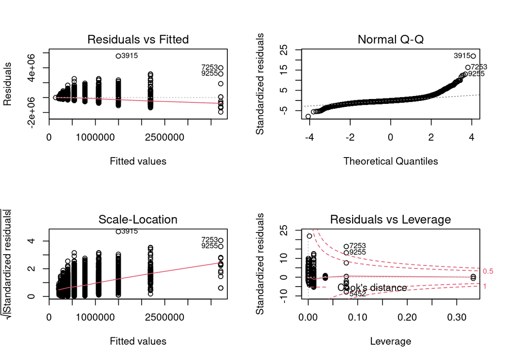

```r
# grade is significant, let's keep it. Now plot diagnostics
par(mfrow = c(2, 2))
plot(mod1b)
```

```r
houses_resid <- houses_tidy %>%
  add_residuals(mod1b) %>%
  select(-c("price", "grade"))

houses_resid_numeric <- houses_resid %>%
  select_if(is.numeric)

houses_resid_nonnumeric <- houses_resid %>%
  select_if(function(x) !is.numeric(x))

houses_resid_nonnumeric$resid <- houses_resid$resid
```

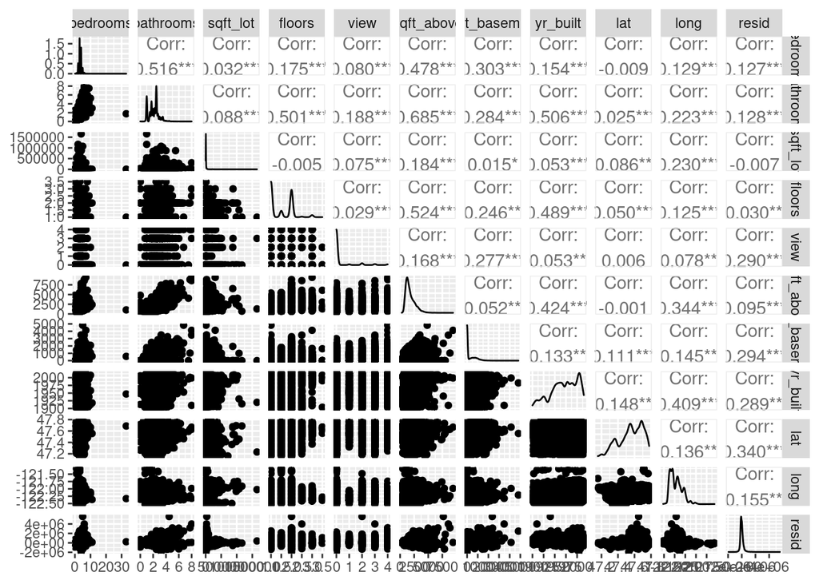

```r
ggpairs(houses_resid_numeric)
```

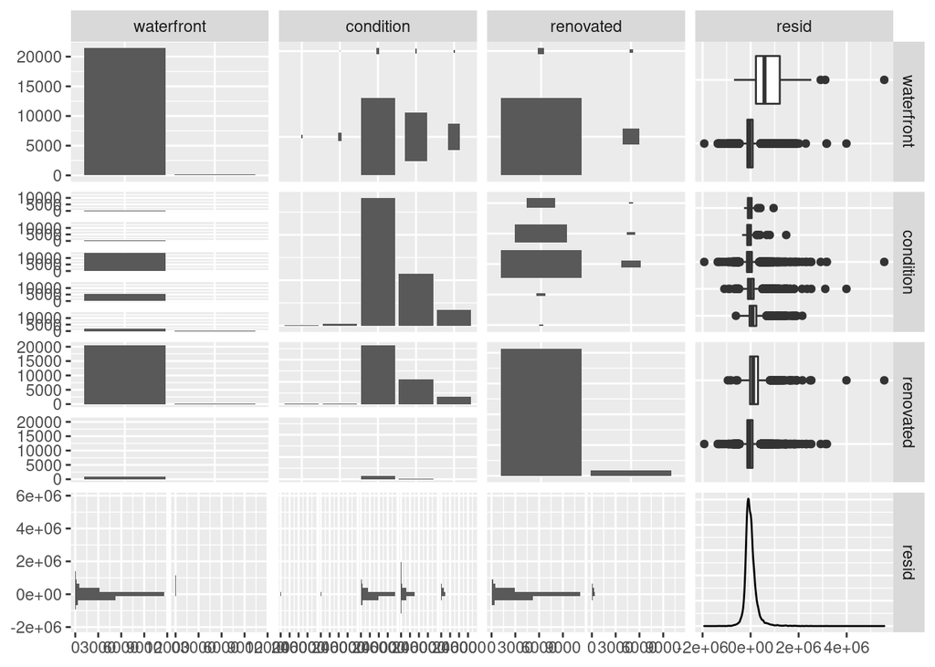

```r
ggpairs(houses_resid_nonnumeric)
```

`lat` has highest correlation with residuals, but, again, `waterfront` still looks pretty promising. Try both…

```r
mod2a <- lm(price ~ grade + lat, data = houses_tidy)
summary(mod2a)
```

```
##
## Call:
## lm(formula = price ~ grade + lat, data = houses_tidy)
##
## Residuals:
##      Min       1Q   Median       3Q      Max
## -1863783  -112379   -28181    67454  5533910
##
## Coefficients:
##              Estimate Std. Error t value Pr(>|t|)
## (Intercept) -29949769     610666 -49.044  < 2e-16 ***
## grade3         187923     276126   0.681 0.496151
## grade4          95367     243212   0.392 0.694978
## grade5         126354     239618   0.527 0.597980
## grade6         158453     239183   0.662 0.507673
## grade7         246275     239138   1.030 0.303093
## grade8         378635     239144   1.583 0.113369
## grade9         603010     239170   2.521 0.011701 *
## grade10        891752     239230   3.728 0.000194 ***
## grade11       1311124     239425   5.476  4.4e-08 ***
## grade12       2007093     240450   8.347  < 2e-16 ***
## grade13       3502099     248154  14.113  < 2e-16 ***
## lat            633100      11822  53.554  < 2e-16 ***
## ---
## Signif. codes:  0 '***' 0.001 '**' 0.01 '*' 0.05 '.' 0.1 ' ' 1
##
## Residual standard error: 239100 on 21600 degrees of freedom
## Multiple R-squared:  0.576,  Adjusted R-squared:  0.5758
## F-statistic:  2445 on 12 and 21600 DF,  p-value: < 2.2e-16
```

```r
mod2b <- lm(price ~ grade + waterfront, data = houses_tidy)
summary(mod2b)
```

```
##
## Call:
## lm(formula = price ~ grade + waterfront, data = houses_tidy)
##
## Residuals:
##      Min       1Q   Median       3Q      Max
## -1929615  -132969   -32393    91481  4778940
##
## Coefficients:
##                Estimate Std. Error t value Pr(>|t|)
## (Intercept)      142000     244366   0.581   0.5612
## grade3            63667     282169   0.226   0.8215
## grade4            72381     248543   0.291   0.7709
## grade5            92834     244870   0.379   0.7046
## grade6           155043     244426   0.634   0.5259
## grade7           258469     244379   1.058   0.2902
## grade8           395393     244386   1.618   0.1057
## grade9           623595     244413   2.551   0.0107 *
## grade10          909321     244474   3.719   0.0002 ***
## grade11         1313326     244674   5.368 8.06e-08 ***
## grade12         1947993     245731   7.927 2.35e-15 ***
## grade13         3567615     253590  14.068  < 2e-16 ***
## waterfrontTRUE   828234      19363  42.773  < 2e-16 ***
## ---
## Signif. codes:  0 '***' 0.001 '**' 0.01 '*' 0.05 '.' 0.1 ' ' 1
##
## Residual standard error: 244400 on 21600 degrees of freedom
## Multiple R-squared:  0.5572, Adjusted R-squared:  0.557
## F-statistic:  2265 on 12 and 21600 DF,  p-value: < 2.2e-16
```

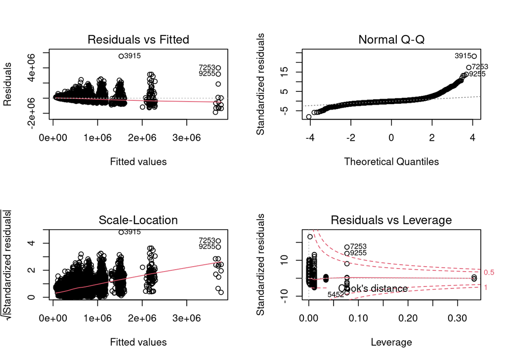

```r
# lat is significant and higher r^2, let's keep model2a
par(mfrow = c(2, 2))
plot(mod2a)
```

```r
houses_resid <- houses_tidy %>%
  add_residuals(mod2a) %>%
  select(-c("price", "grade", "lat"))

houses_resid_numeric <- houses_resid %>%
  select_if(is.numeric)

houses_resid_nonnumeric <- houses_resid %>%
  select_if(function(x) !is.numeric(x))

houses_resid_nonnumeric$resid <- houses_resid$resid
```

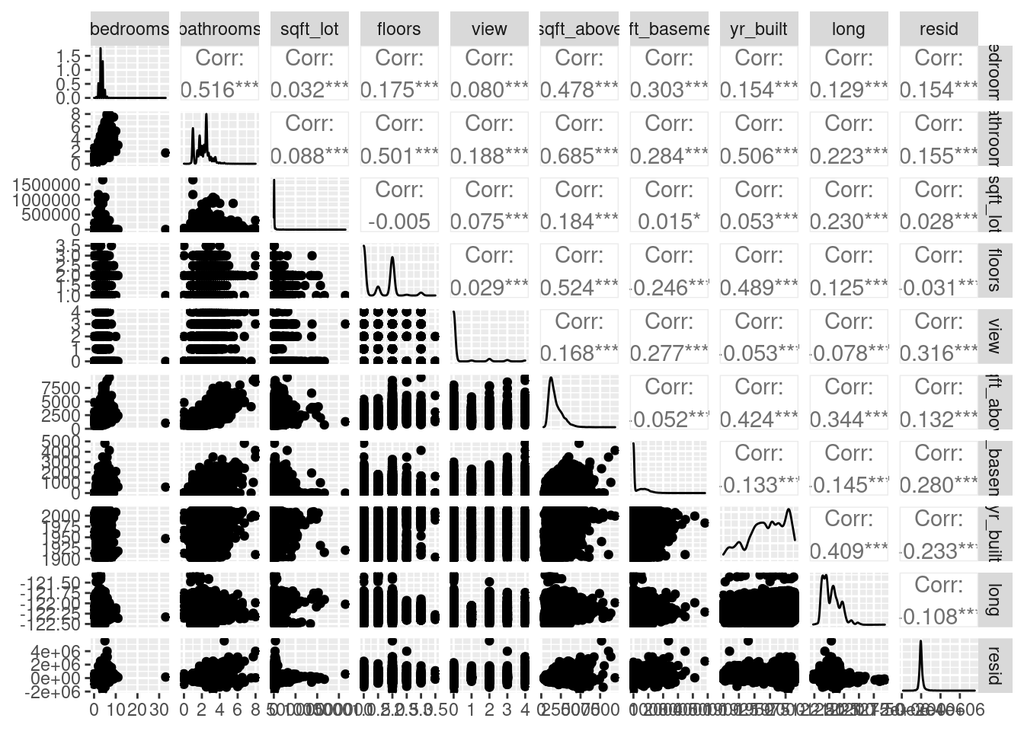

```r
ggpairs(houses_resid_numeric)
```

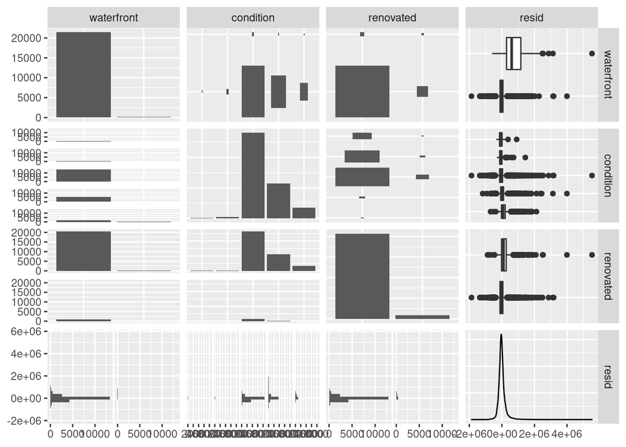

```r
ggpairs(houses_resid_nonnumeric)
```

Now `view` has strongest correlation with residuals, but also compare against model with `waterfront`.

```r
mod3a <- lm(price ~ grade + lat + view, data = houses_tidy)
summary(mod3a)
```

```
##
## Call:
## lm(formula = price ~ grade + lat + view, data = houses_tidy)
##
## Residuals:
##      Min       1Q   Median       3Q      Max
## -1665265  -105866   -21393    69623  5429667
##
## Coefficients:
##              Estimate Std. Error t value Pr(>|t|)
## (Intercept) -30514024     576750 -52.907  < 2e-16 ***
## grade3         190253     260743   0.730 0.465607
## grade4          81058     229663   0.353 0.724133
## grade5         112154     226269   0.496 0.620134
## grade6         148515     225858   0.658 0.510827
## grade7         235345     225815   1.042 0.297328
## grade8         351873     225822   1.558 0.119203
## grade9         556584     225848   2.464 0.013731 *
## grade10        821118     225907   3.635 0.000279 ***
## grade11       1200228     226097   5.308 1.12e-07 ***
## grade12       1832950     227080   8.072 7.28e-16 ***
## grade13       3303587     234361  14.096  < 2e-16 ***
## lat            644972      11166  57.764  < 2e-16 ***
## view           106862       2086  51.234  < 2e-16 ***
## ---
## Signif. codes:  0 '***' 0.001 '**' 0.01 '*' 0.05 '.' 0.1 ' ' 1
##
## Residual standard error: 225800 on 21599 degrees of freedom
## Multiple R-squared:  0.6219, Adjusted R-squared:  0.6217
## F-statistic:  2733 on 13 and 21599 DF,  p-value: < 2.2e-16
```

```r
mod3b <- lm(price ~ grade + lat + waterfront, data = houses_tidy)
summary(mod3b)
```

```
##
## Call:
## lm(formula = price ~ grade + lat + waterfront, data = houses_tidy)
##
## Residuals:
##      Min       1Q   Median       3Q      Max
## -1862555  -109244   -24781    70145  4724767
##
## Coefficients:
##                 Estimate Std. Error t value Pr(>|t|)
## (Intercept)    -30511083     581588 -52.462  < 2e-16 ***
## grade3            190241     262923   0.724 0.469343
## grade4             95796     231583   0.414 0.679130
## grade5            112654     228161   0.494 0.621488
## grade6            153414     227746   0.674 0.500562
## grade7            243828     227703   1.071 0.284264
## grade8            372609     227709   1.636 0.101783
## grade9            594340     227734   2.610 0.009066 **
## grade10           870026     227792   3.819 0.000134 ***
## grade11          1267641     227979   5.560 2.72e-08 ***
## grade12          1902270     228964   8.308  < 2e-16 ***
## grade13          3500877     236288  14.816  < 2e-16 ***
## lat               644910      11259  57.278  < 2e-16 ***
## waterfrontTRUE    851219      18046  47.168  < 2e-16 ***
## ---
## Signif. codes:  0 '***' 0.001 '**' 0.01 '*' 0.05 '.' 0.1 ' ' 1
##
## Residual standard error: 227700 on 21599 degrees of freedom
## Multiple R-squared:  0.6156, Adjusted R-squared:  0.6154
## F-statistic:  2661 on 13 and 21599 DF,  p-value: < 2.2e-16
```

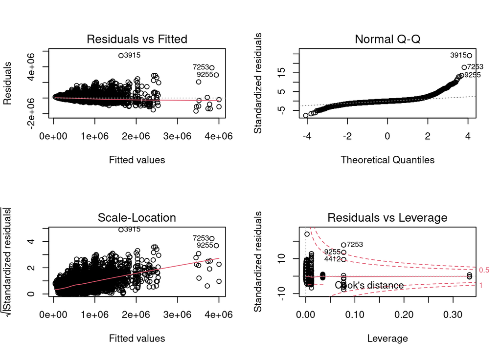

```r
# view model is best, keep mod3a
par(mfrow = c(2, 2))
plot(mod3a)
```

```r
houses_resid <- houses_tidy %>%
  add_residuals(mod3a) %>%
  select(-c("price", "grade", "lat", "view"))

houses_resid_numeric <- houses_resid %>%
  select_if(is.numeric)

houses_resid_nonnumeric <- houses_resid %>%
  select_if(function(x) !is.numeric(x))

houses_resid_nonnumeric$resid <- houses_resid$resid
```

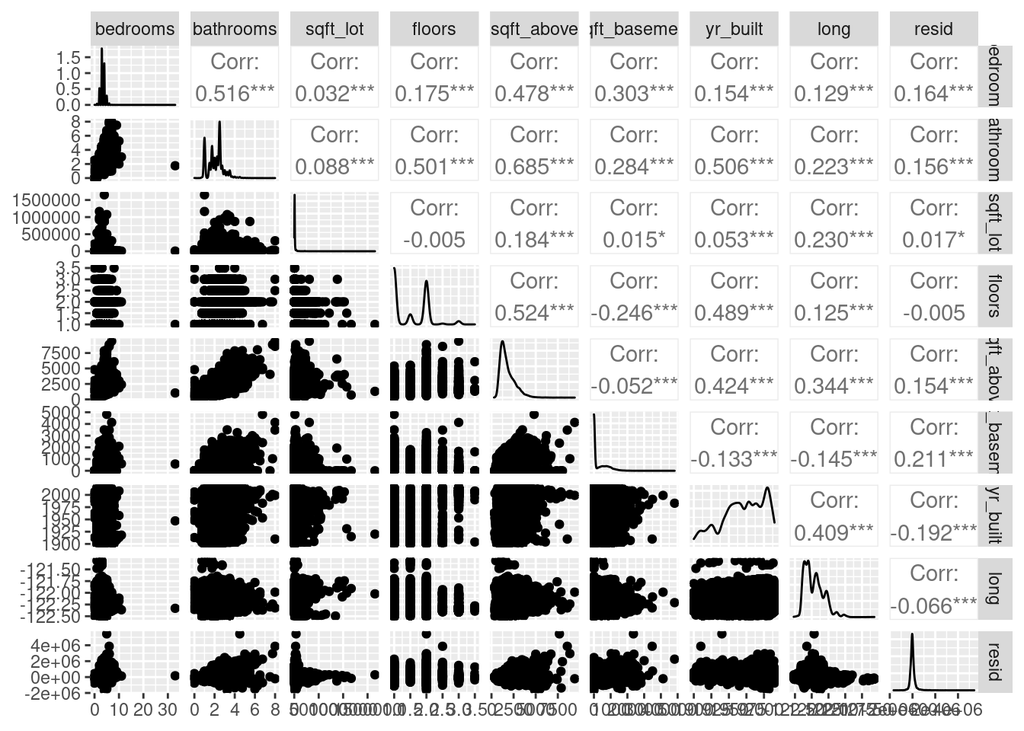

```r
ggpairs(houses_resid_numeric)
```

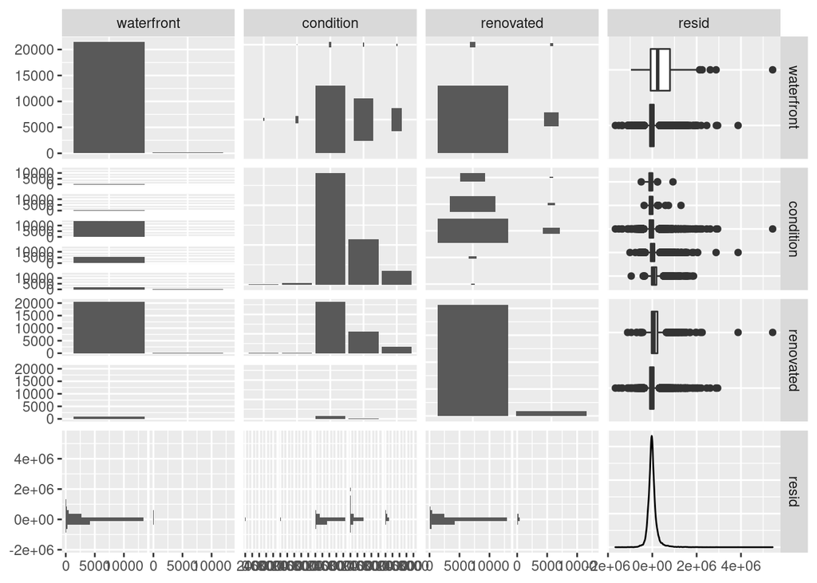

```r
ggpairs(houses_resid_nonnumeric)
```

`sqft_basement` has highest correlation with residuals. Let’s test against all remaining categorical predictors:

```r
mod4a <- lm(price ~ grade + lat + view + sqft_basement, data = houses_tidy)
summary(mod4a)
```

```
##
## Call:
## lm(formula = price ~ grade + lat + view + sqft_basement, data = houses_tidy)
##
## Residuals:
##      Min       1Q   Median       3Q      Max
## -1569582  -105308   -18663    70867  5230039
##
## Coefficients:
##                 Estimate Std. Error t value Pr(>|t|)
## (Intercept)   -2.875e+07  5.647e+05 -50.913  < 2e-16 ***
## grade3         1.830e+05  2.542e+05   0.720  0.47164
## grade4         8.134e+04  2.239e+05   0.363  0.71638
## grade5         1.088e+05  2.206e+05   0.493  0.62197
## grade6         1.355e+05  2.202e+05   0.615  0.53841
## grade7         2.042e+05  2.201e+05   0.927  0.35373
## grade8         3.194e+05  2.201e+05   1.451  0.14687
## grade9         5.281e+05  2.202e+05   2.399  0.01646 *
## grade10        7.859e+05  2.202e+05   3.568  0.00036 ***
## grade11        1.156e+06  2.204e+05   5.244 1.59e-07 ***
## grade12        1.765e+06  2.214e+05   7.974 1.61e-15 ***
## grade13        3.169e+06  2.285e+05  13.869  < 2e-16 ***
## lat            6.079e+05  1.094e+04  55.559  < 2e-16 ***
## view           8.903e+04  2.101e+03  42.367  < 2e-16 ***
## sqft_basement  1.204e+02  3.582e+00  33.600  < 2e-16 ***
## ---
## Signif. codes:  0 '***' 0.001 '**' 0.01 '*' 0.05 '.' 0.1 ' ' 1
##
## Residual standard error: 220100 on 21598 degrees of freedom
## Multiple R-squared:  0.6407, Adjusted R-squared:  0.6405
## F-statistic:  2751 on 14 and 21598 DF,  p-value: < 2.2e-16
```

```r
mod4b <- lm(price ~ grade + lat + view + waterfront, data = houses_tidy)
summary(mod4b)
```

```
##
## Call:
## lm(formula = price ~ grade + lat + view + waterfront, data = houses_tidy)
##
## Residuals:
##      Min       1Q   Median       3Q      Max
## -1713543  -105538   -20871    69842  4901827
##
## Coefficients:
##                 Estimate Std. Error t value Pr(>|t|)
## (Intercept)    -30758475     564698 -54.469  < 2e-16 ***
## grade3            191262     255269   0.749 0.453709
## grade4             84892     224841   0.378 0.705758
## grade5            106294     221518   0.480 0.631345
## grade6            147526     221116   0.667 0.504659
## grade7            236375     221074   1.069 0.284985
## grade8            354372     221081   1.603 0.108970
## grade9            562139     221106   2.542 0.011016 *
## grade10           823728     221164   3.725 0.000196 ***
## grade11          1197915     221350   5.412 6.30e-08 ***
## grade12          1804315     222314   8.116 5.07e-16 ***
## grade13          3351868     229446  14.609  < 2e-16 ***
## lat               650115      10932  59.466  < 2e-16 ***
## view               80422       2217  36.273  < 2e-16 ***
## waterfrontTRUE    582422      19024  30.615  < 2e-16 ***
## ---
## Signif. codes:  0 '***' 0.001 '**' 0.01 '*' 0.05 '.' 0.1 ' ' 1
##
## Residual standard error: 221100 on 21598 degrees of freedom
## Multiple R-squared:  0.6377, Adjusted R-squared:  0.6374
## F-statistic:  2715 on 14 and 21598 DF,  p-value: < 2.2e-16
```

```r
mod4c <- lm(price ~ grade + lat + view + condition, data = houses_tidy)
summary(mod4c)
```

```
##
## Call:
## lm(formula = price ~ grade + lat + view + condition, data = houses_tidy)
##
## Residuals:
##      Min       1Q   Median       3Q      Max
## -1665132  -105472   -18392    71578  5447648
##
## Coefficients:
##               Estimate Std. Error t value Pr(>|t|)
## (Intercept) -3.043e+07  5.673e+05 -53.640  < 2e-16 ***
## grade3       1.472e+05  2.595e+05   0.567 0.570486
## grade4       6.481e+04  2.291e+05   0.283 0.777293
## grade5       7.656e+04  2.258e+05   0.339 0.734605
## grade6       1.165e+05  2.257e+05   0.516 0.605628
## grade7       2.090e+05  2.257e+05   0.926 0.354406
## grade8       3.359e+05  2.257e+05   1.488 0.136720
## grade9       5.476e+05  2.257e+05   2.426 0.015270 *
## grade10      8.154e+05  2.258e+05   3.612 0.000305 ***
## grade11      1.199e+06  2.260e+05   5.307 1.12e-07 ***
## grade12      1.834e+06  2.269e+05   8.082 6.69e-16 ***
## grade13      3.310e+06  2.339e+05  14.148  < 2e-16 ***
## lat          6.432e+05  1.098e+04  58.552  < 2e-16 ***
## view         1.017e+05  2.058e+03  49.425  < 2e-16 ***
## condition2  -4.275e+02  4.466e+04  -0.010 0.992363
## condition3  -6.453e+03  4.154e+04  -0.155 0.876556
## condition4   5.758e+04  4.158e+04   1.385 0.166054
## condition5   1.349e+05  4.180e+04   3.226 0.001258 **
## ---
## Signif. codes:  0 '***' 0.001 '**' 0.01 '*' 0.05 '.' 0.1 ' ' 1
##
## Residual standard error: 221800 on 21595 degrees of freedom
## Multiple R-squared:  0.6352, Adjusted R-squared:  0.635
## F-statistic:  2212 on 17 and 21595 DF,  p-value: < 2.2e-16
```

```r
mod4d <- lm(price ~ grade + lat + view + renovated, data = houses_tidy)
summary(mod4d)
```

```
##
## Call:
## lm(formula = price ~ grade + lat + view + renovated, data = houses_tidy)
##
## Residuals:
##      Min       1Q   Median       3Q      Max
## -1637628  -105101   -19410    70577  5280904
##
## Coefficients:
##                Estimate Std. Error t value Pr(>|t|)
## (Intercept)   -30179084     571198 -52.835  < 2e-16 ***
## grade3           188870     258132   0.732 0.464372
## grade4            75932     227363   0.334 0.738407
## grade5           108602     224003   0.485 0.627808
## grade6           141362     223596   0.632 0.527250
## grade7           229992     223554   1.029 0.303586
## grade8           346281     223561   1.549 0.121413
## grade9           550447     223587   2.462 0.013828 *
## grade10          817501     223645   3.655 0.000257 ***
## grade11         1199432     223833   5.359 8.47e-08 ***
## grade12         1835525     224806   8.165 3.39e-16 ***
## grade13         3275946     232018  14.119  < 2e-16 ***
## lat              637925      11059  57.684  < 2e-16 ***
## view             102285       2076  49.261  < 2e-16 ***
## renovatedTRUE    159554       7606  20.979  < 2e-16 ***
## ---
## Signif. codes:  0 '***' 0.001 '**' 0.01 '*' 0.05 '.' 0.1 ' ' 1
##
## Residual standard error: 223500 on 21598 degrees of freedom
## Multiple R-squared:  0.6295, Adjusted R-squared:  0.6292
## F-statistic:  2621 on 14 and 21598 DF,  p-value: < 2.2e-16
```

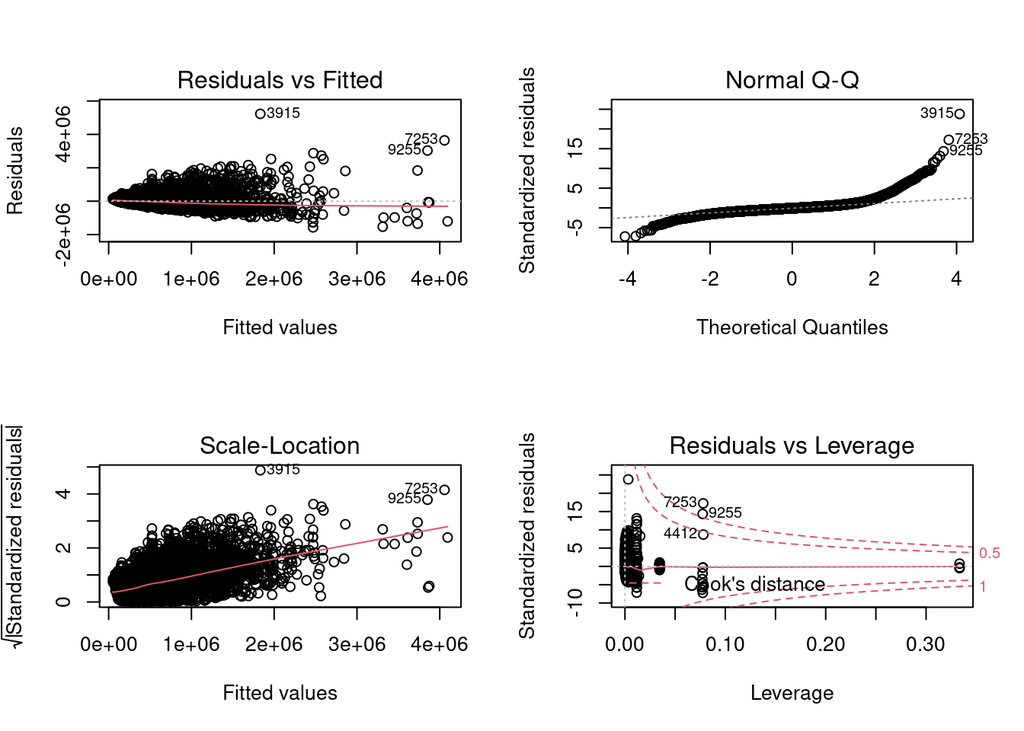

```r
# looks like model with sqft_basement is best, keep mod4a
par(mfrow = c(2, 2))
plot(mod4a)
```

```r
houses_resid <- houses_tidy %>%
  add_residuals(mod4a) %>%
  select(- price)
```

Our final model in terms of main effects is: `price ~ grade + lat + view + sqft_basement`

# 2 Extensions

- Consider possible interactions between your four main effect predictors and test their effect upon $r^2$. Choose your best candidate interaction and visualise its effect.
- Calculate the relative importance of predictors from your best $4$-predictor model (i.e. the model without an interaction). Which predictor affects `price` most strongly?

**Solution**

Now, for interactions, have six possibilities that obey principle of strong hierarchy (i.e. consider including an interaction only if its main effects are already present in the model)

```r
mod5a <- lm(price ~ grade + lat + view + sqft_basement + grade:lat, data = houses_tidy)
summary(mod5a)
```

```
##
## Call:
## lm(formula = price ~ grade + lat + view + sqft_basement + grade:lat,
##     data = houses_tidy)
##
## Residuals:
##      Min       1Q   Median       3Q      Max
## -1496592  -101302   -20837    67958  5196329
##
## Coefficients: (1 not defined because of singularities)
##                 Estimate Std. Error t value Pr(>|t|)
## (Intercept)   -4.375e+07  4.424e+07  -0.989   0.3228
## grade3         3.068e+07  6.120e+07   0.501   0.6162
## grade4         3.760e+07  4.798e+07   0.784   0.4332
## grade5         2.917e+07  4.457e+07   0.654   0.5129
## grade6         2.420e+07  4.428e+07   0.546   0.5848
## grade7         1.912e+07  4.425e+07   0.432   0.6656
## grade8         1.546e+07  4.425e+07   0.349   0.7267
## grade9        -7.530e+05  4.427e+07  -0.017   0.9864
## grade10       -1.492e+07  4.435e+07  -0.336   0.7366
## grade11       -1.469e+07  4.466e+07  -0.329   0.7422
## grade12       -8.399e+07  4.632e+07  -1.813   0.0698 .
## grade13        3.135e+06  2.463e+05  12.728   <2e-16 ***
## lat            9.234e+05  9.308e+05   0.992   0.3212
## view           8.949e+04  2.086e+03  42.892   <2e-16 ***
## sqft_basement  1.208e+02  3.556e+00  33.968   <2e-16 ***
## grade3:lat    -6.429e+05  1.290e+06  -0.498   0.6183
## grade4:lat    -7.898e+05  1.010e+06  -0.782   0.4340
## grade5:lat    -6.115e+05  9.378e+05  -0.652   0.5143
## grade6:lat    -5.062e+05  9.315e+05  -0.543   0.5869
## grade7:lat    -3.980e+05  9.310e+05  -0.428   0.6690
## grade8:lat    -3.186e+05  9.310e+05  -0.342   0.7322
## grade9:lat     2.662e+04  9.315e+05   0.029   0.9772
## grade10:lat    3.296e+05  9.330e+05   0.353   0.7239
## grade11:lat    3.325e+05  9.395e+05   0.354   0.7234
## grade12:lat    1.801e+06  9.745e+05   1.848   0.0646 .
## grade13:lat           NA         NA      NA       NA
## ---
## Signif. codes:  0 '***' 0.001 '**' 0.01 '*' 0.05 '.' 0.1 ' ' 1
##
## Residual standard error: 218400 on 21588 degrees of freedom
## Multiple R-squared:  0.6464, Adjusted R-squared:  0.646
## F-statistic:  1644 on 24 and 21588 DF,  p-value: < 2.2e-16
```

```r
mod5b <- lm(price ~ grade + lat + view + sqft_basement + grade:view, data = houses_tidy)
summary(mod5b)
```

```
##
## Call:
## lm(formula = price ~ grade + lat + view + sqft_basement + grade:view,
##     data = houses_tidy)
##
## Residuals:
##      Min       1Q   Median       3Q      Max
## -1878838  -104533   -20264    69483  5165978
##
## Coefficients: (2 not defined because of singularities)
##                 Estimate Std. Error t value Pr(>|t|)
## (Intercept)   -2.871e+07  5.606e+05 -51.208  < 2e-16 ***
## grade3         1.828e+05  2.523e+05   0.725 0.468734
## grade4         8.617e+04  2.226e+05   0.387 0.698645
## grade5         1.122e+05  2.189e+05   0.513 0.608291
## grade6         1.379e+05  2.185e+05   0.631 0.528067
## grade7         2.081e+05  2.185e+05   0.952 0.340866
## grade8         3.222e+05  2.185e+05   1.475 0.140313
## grade9         5.373e+05  2.185e+05   2.459 0.013953 *
## grade10        7.518e+05  2.186e+05   3.439 0.000585 ***
## grade11        1.084e+06  2.189e+05   4.953 7.35e-07 ***
## grade12        1.741e+06  2.208e+05   7.887 3.23e-15 ***
## grade13        2.594e+06  2.372e+05  10.939  < 2e-16 ***
## lat            6.070e+05  1.086e+04  55.879  < 2e-16 ***
## view           4.024e+05  3.764e+04  10.689  < 2e-16 ***
## sqft_basement  1.178e+02  3.570e+00  32.987  < 2e-16 ***
## grade3:view           NA         NA      NA       NA
## grade4:view   -3.485e+05  1.009e+05  -3.454 0.000553 ***
## grade5:view   -3.381e+05  4.384e+04  -7.712 1.29e-14 ***
## grade6:view   -3.360e+05  3.893e+04  -8.631  < 2e-16 ***
## grade7:view   -3.454e+05  3.794e+04  -9.104  < 2e-16 ***
## grade8:view   -3.214e+05  3.782e+04  -8.498  < 2e-16 ***
## grade9:view   -3.326e+05  3.788e+04  -8.782  < 2e-16 ***
## grade10:view  -2.595e+05  3.800e+04  -6.828 8.81e-12 ***
## grade11:view  -2.424e+05  3.843e+04  -6.307 2.89e-10 ***
## grade12:view  -2.972e+05  4.002e+04  -7.428 1.14e-13 ***
## grade13:view          NA         NA      NA       NA
## ---
## Signif. codes:  0 '***' 0.001 '**' 0.01 '*' 0.05 '.' 0.1 ' ' 1
##
## Residual standard error: 218500 on 21589 degrees of freedom
## Multiple R-squared:  0.6462, Adjusted R-squared:  0.6459
## F-statistic:  1715 on 23 and 21589 DF,  p-value: < 2.2e-16
```

```r
mod5c <- lm(price ~ grade + lat + view + sqft_basement + grade:sqft_basement, data = houses_tidy)
summary(mod5c)
```

```
##
## Call:
## lm(formula = price ~ grade + lat + view + sqft_basement + grade:sqft_basement,
##     data = houses_tidy)
##
## Residuals:
##      Min       1Q   Median       3Q      Max
## -2093544  -102714   -19903    68417  4922552
##
## Coefficients: (2 not defined because of singularities)
##                         Estimate Std. Error t value Pr(>|t|)
## (Intercept)           -2.922e+07  5.576e+05 -52.398  < 2e-16 ***
## grade3                 1.849e+05  2.507e+05   0.737 0.460910
## grade4                 7.737e+04  2.210e+05   0.350 0.726274
## grade5                 1.098e+05  2.176e+05   0.504 0.613935
## grade6                 1.427e+05  2.172e+05   0.657 0.511185
## grade7                 2.183e+05  2.172e+05   1.005 0.314862
## grade8                 3.305e+05  2.172e+05   1.522 0.128016
## grade9                 5.195e+05  2.172e+05   2.392 0.016782 *
## grade10                7.595e+05  2.173e+05   3.495 0.000475 ***
## grade11                1.067e+06  2.176e+05   4.906 9.38e-07 ***
## grade12                1.603e+06  2.191e+05   7.318 2.61e-13 ***
## grade13                2.047e+06  2.372e+05   8.629  < 2e-16 ***
## lat                    6.177e+05  1.080e+04  57.166  < 2e-16 ***
## view                   8.401e+04  2.100e+03  40.011  < 2e-16 ***
## sqft_basement          9.153e+02  5.204e+01  17.589  < 2e-16 ***
## grade3:sqft_basement          NA         NA      NA       NA
## grade4:sqft_basement  -6.667e+01  1.106e+03  -0.060 0.951943
## grade5:sqft_basement  -7.957e+02  1.065e+02  -7.470 8.33e-14 ***
## grade6:sqft_basement  -8.503e+02  5.511e+01 -15.429  < 2e-16 ***
## grade7:sqft_basement  -8.442e+02  5.238e+01 -16.118  < 2e-16 ***
## grade8:sqft_basement  -8.273e+02  5.241e+01 -15.785  < 2e-16 ***
## grade9:sqft_basement  -7.618e+02  5.272e+01 -14.451  < 2e-16 ***
## grade10:sqft_basement -7.237e+02  5.317e+01 -13.611  < 2e-16 ***
## grade11:sqft_basement -6.234e+02  5.421e+01 -11.499  < 2e-16 ***
## grade12:sqft_basement -5.887e+02  5.646e+01 -10.427  < 2e-16 ***
## grade13:sqft_basement         NA         NA      NA       NA
## ---
## Signif. codes:  0 '***' 0.001 '**' 0.01 '*' 0.05 '.' 0.1 ' ' 1
##
## Residual standard error: 217100 on 21589 degrees of freedom
## Multiple R-squared:  0.6505, Adjusted R-squared:  0.6502
## F-statistic:  1747 on 23 and 21589 DF,  p-value: < 2.2e-16
```

```r
mod5d <- lm(price ~ grade + lat + view + sqft_basement + lat:view, data = houses_tidy)
summary(mod5d)
```

```
##
## Call:
## lm(formula = price ~ grade + lat + view + sqft_basement + lat:view,
##     data = houses_tidy)
##
## Residuals:
##      Min       1Q   Median       3Q      Max
## -1544431  -103361   -20451    68950  5201833
##
## Coefficients:
##                 Estimate Std. Error t value Pr(>|t|)
## (Intercept)   -2.680e+07  5.780e+05 -46.362  < 2e-16 ***
## grade3         1.749e+05  2.530e+05   0.691 0.489328
## grade4         7.915e+04  2.228e+05   0.355 0.722429
## grade5         1.100e+05  2.195e+05   0.501 0.616167
## grade6         1.372e+05  2.191e+05   0.626 0.531099
## grade7         2.062e+05  2.191e+05   0.941 0.346529
## grade8         3.209e+05  2.191e+05   1.464 0.143085
## grade9         5.296e+05  2.191e+05   2.417 0.015660 *
## grade10        7.858e+05  2.192e+05   3.585 0.000338 ***
## grade11        1.152e+06  2.194e+05   5.251 1.53e-07 ***
## grade12        1.757e+06  2.203e+05   7.974 1.61e-15 ***
## grade13        3.133e+06  2.274e+05  13.776  < 2e-16 ***
## lat            5.668e+05  1.125e+04  50.366  < 2e-16 ***
## view          -1.069e+07  7.448e+05 -14.352  < 2e-16 ***
## sqft_basement  1.188e+02  3.567e+00  33.320  < 2e-16 ***
## lat:view       2.266e+05  1.566e+04  14.471  < 2e-16 ***
## ---
## Signif. codes:  0 '***' 0.001 '**' 0.01 '*' 0.05 '.' 0.1 ' ' 1
##
## Residual standard error: 219100 on 21597 degrees of freedom
## Multiple R-squared:  0.6442, Adjusted R-squared:  0.6439
## F-statistic:  2607 on 15 and 21597 DF,  p-value: < 2.2e-16
```

```r
mod5e <- lm(price ~ grade + lat + view + sqft_basement + lat:sqft_basement, data = houses_tidy)
summary(mod5e)
```

```
##
## Call:
## lm(formula = price ~ grade + lat + view + sqft_basement + lat:sqft_basement,
##     data = houses_tidy)
##
## Residuals:
##      Min       1Q   Median       3Q      Max
## -1550147  -101737   -18763    68303  5174888
##
## Coefficients:
##                     Estimate Std. Error t value Pr(>|t|)
## (Intercept)       -2.488e+07  6.359e+05 -39.124  < 2e-16 ***
## grade3             1.670e+05  2.532e+05   0.659 0.509600
## grade4             7.862e+04  2.230e+05   0.353 0.724442
## grade5             1.072e+05  2.197e+05   0.488 0.625492
## grade6             1.362e+05  2.193e+05   0.621 0.534705
## grade7             2.060e+05  2.193e+05   0.939 0.347638
## grade8             3.210e+05  2.193e+05   1.464 0.143228
## grade9             5.299e+05  2.193e+05   2.416 0.015700 *
## grade10            7.885e+05  2.194e+05   3.594 0.000326 ***
## grade11            1.158e+06  2.196e+05   5.274 1.35e-07 ***
## grade12            1.765e+06  2.205e+05   8.004 1.26e-15 ***
## grade13            3.143e+06  2.276e+05  13.809  < 2e-16 ***
## lat                5.264e+05  1.256e+04  41.918  < 2e-16 ***
## view               8.911e+04  2.093e+03  42.569  < 2e-16 ***
## sqft_basement     -1.698e+04  1.310e+03 -12.968  < 2e-16 ***
## lat:sqft_basement  3.595e+02  2.752e+01  13.060  < 2e-16 ***
## ---
## Signif. codes:  0 '***' 0.001 '**' 0.01 '*' 0.05 '.' 0.1 ' ' 1
##
## Residual standard error: 219300 on 21597 degrees of freedom
## Multiple R-squared:  0.6435, Adjusted R-squared:  0.6433
## F-statistic:  2599 on 15 and 21597 DF,  p-value: < 2.2e-16
```

```r
mod5f <- lm(price ~ grade + lat + view + sqft_basement + view:sqft_basement, data = houses_tidy)
summary(mod5f)
```

```
##
## Call:
## lm(formula = price ~ grade + lat + view + sqft_basement + view:sqft_basement,
##     data = houses_tidy)
##
## Residuals:
##      Min       1Q   Median       3Q      Max
## -1638784  -104221   -19570    69709  5166209
##
## Coefficients:
##                      Estimate Std. Error t value Pr(>|t|)
## (Intercept)        -2.883e+07  5.636e+05 -51.155  < 2e-16 ***
## grade3              1.833e+05  2.537e+05   0.723 0.469931
## grade4              8.399e+04  2.234e+05   0.376 0.707022
## grade5              1.118e+05  2.201e+05   0.508 0.611432
## grade6              1.385e+05  2.197e+05   0.630 0.528579
## grade7              2.087e+05  2.197e+05   0.950 0.342139
## grade8              3.238e+05  2.197e+05   1.474 0.140599
## grade9              5.312e+05  2.197e+05   2.417 0.015645 *
## grade10             7.884e+05  2.198e+05   3.587 0.000335 ***
## grade11             1.155e+06  2.200e+05   5.250 1.54e-07 ***
## grade12             1.742e+06  2.210e+05   7.886 3.27e-15 ***
## grade13             3.138e+06  2.281e+05  13.756  < 2e-16 ***
## lat                 6.096e+05  1.092e+04  55.822  < 2e-16 ***
## view                7.106e+04  2.847e+03  24.962  < 2e-16 ***
## sqft_basement       1.056e+02  3.910e+00  27.003  < 2e-16 ***
## view:sqft_basement  2.870e+01  3.073e+00   9.339  < 2e-16 ***
## ---
## Signif. codes:  0 '***' 0.001 '**' 0.01 '*' 0.05 '.' 0.1 ' ' 1
##
## Residual standard error: 219700 on 21597 degrees of freedom
## Multiple R-squared:  0.6422, Adjusted R-squared:  0.6419
## F-statistic:  2584 on 15 and 21597 DF,  p-value: < 2.2e-16
```

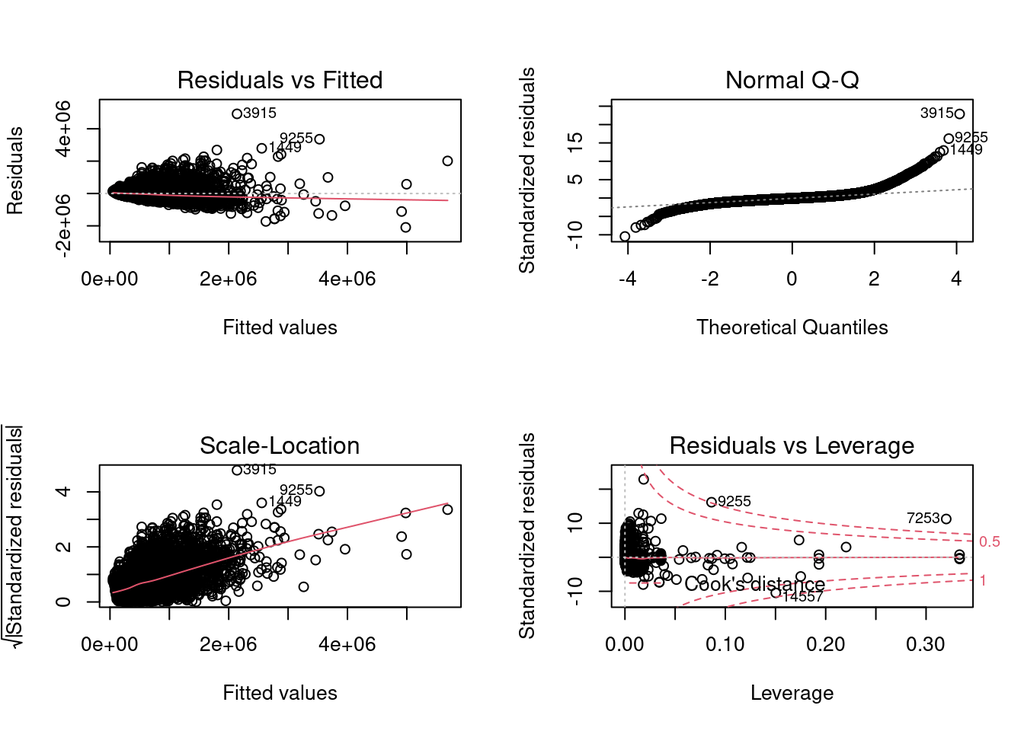

```r
# mod5c looks like the best
par(mfrow = c(2,2))
plot(mod5c)
```

It seems that the `grade:sqft_basement` interaction leads to highest $r^2$ (but two levels of the interaction cannot be determined due to fitting problems).

Now let’s see a visualisation of the effect of this interaction.

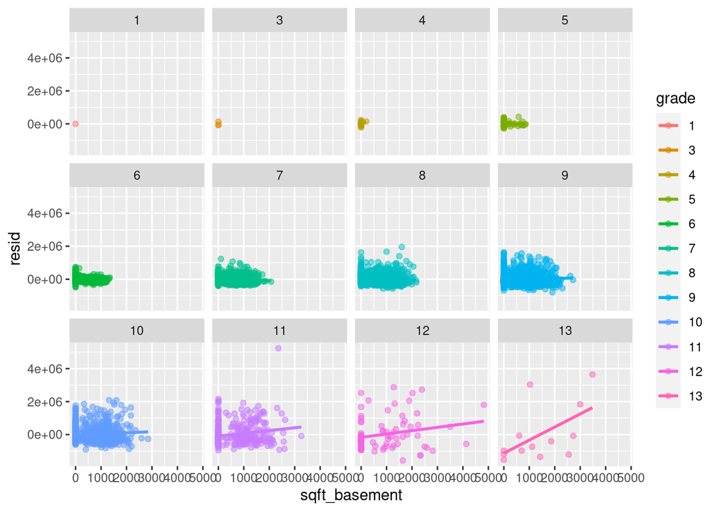

```r
houses_resid %>%
  ggplot(aes(x = sqft_basement, y = resid, colour = grade)) +
  geom_point(alpha = 0.5) +
  geom_smooth(method = "lm", se = FALSE) +
  facet_wrap(~ grade)
```

Relative importance of predictors:

```r
library(relaimpo)
calc.relimp(mod4a, method = "lmg", rela = TRUE)
```

```
## Response variable: price
## Total response variance: 134782378397
## Analysis based on 21613 observations
##
## 14 Regressors:
## Some regressors combined in groups:
##         Group  grade : grade3 grade4 grade5 grade6 grade7 grade8 grade9 grade10 grade11 grade12 grade13
##
##  Relative importance of 4 (groups of) regressors assessed:
##  grade lat view sqft_basement
##
## Proportion of variance explained by model: 64.07%
## Metrics are normalized to sum to 100% (rela=TRUE).
##
## Relative importance metrics:
##
##                      lmg
## grade         0.67013680
## lat           0.10999806
## view          0.13594911
## sqft_basement 0.08391603
##
## Average coefficients for different model sizes:
##
##                     1group      2groups      3groups      4groups
## grade3          63666.6672  105085.5034  144251.4794  182970.8245
## grade4          72381.0351   74840.3850   77838.0192   81340.5229
## grade5         106523.9716  106120.0182  106860.8796  108762.8919
## grade6         159919.6380  148997.5902  140821.1511  135460.9340
## grade7         260590.2629  235879.0272  216962.5200  204157.6486
## grade8         400852.7662  366263.3497  339139.6632  319376.1318
## grade9         631513.1864  588676.4480  554462.1758  528149.5236
## grade10        929771.0746  870400.5336  822843.4234  785879.9257
## grade11       1354841.7274 1272639.8932 1206980.5470 1155890.1732
## grade12       2049222.0006 1930531.4478 1836851.8205 1765372.6480
## grade13       3567615.3852 3398156.8184 3266023.2283 3169155.3827
## lat            813411.5832  722508.3996  660525.2637  607867.6492
## view           190335.2479  151137.4701  117930.1234   89031.6774
## sqft_basement     268.6136     203.8056     154.5114     120.3599
```